# Binomial Distribution Response to Urban Heat in King County

Joey Hulbert

2024-06-18

| [Welcome](https://jmhulbert.github.io/redhot) | [Data](https://jmhulbert.github.io/redhot/data) | [Analyses](https://jmhulbert.github.io/redhot/analyses) | [Discussion](https://jmhulbert.github.io/redhot/discussion) | [Maps](https://jmhulbert.github.io/redhot/maps) |
| --- | --- | --- | --- | --- |

|  |  |  | Analyses |  |  |  |
| --- | --- | --- | --- | --- | --- | --- |
| [Urban Heat](https://jmhulbert.github.io/redhot/analyses/heat/) | [All Areas](https://jmhulbert.github.io/redhot/analyses/heat/all-areas) | [Portland](https://jmhulbert.github.io/redhot/analyses/heat/portland) | [Tacoma](https://jmhulbert.github.io/redhot/analyses/heat/tacoma) | [King County](https://jmhulbert.github.io/redhot/analyses/heat/king-county) | [iNaturalist](https://jmhulbert.github.io/redhot/analyses/inaturalist/) | City Inventories |

```r
library(tidyverse)
library(corrplot)
library(knitr)
library(kableExtra)
library(gghalves)
library(patchwork)
library(scales)
library(glmmTMB)
library(bbmle)
library(DHARMa)
```

#KING COUNTY

# Purpose

The purpose of this page is to summarize an investigation of **tree health categories** as a *binary* response to urban heat (temperatures) for *trees within King County*.

*Response variables* Binary dead top: no top dieback, top dieback

[figure not shown]

# Read Data

```r
data <- read.csv('https://raw.githubusercontent.com/jmhulbert/redhot/main/data/urban-data-modified.csv')
```

# Wrangle Data

## Remove dead trees

```r
# Remove Dead Trees
data.w.dead <- data
data <- data %>% filter(field.tree.canopy.symptoms!="Tree is dead") %>% filter(field.dieback.percent<100) %>% droplevels()
```

```r
data$binary.tree.canopy.symptoms <- as.factor(data$binary.tree.canopy.symptoms)
levels(data$binary.tree.canopy.symptoms)
```

```
## [1] "Healthy"   "Unhealthy"
```

## Filter to King County Data

```r
data <- data %>% filter(Area=="King County") %>% droplevels()
```

# Visualize King County Data

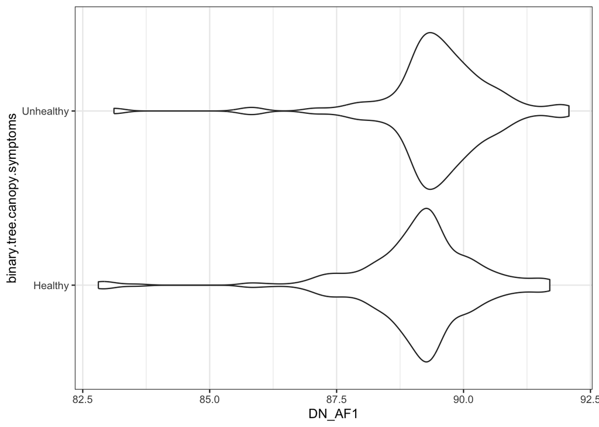

```r
ggplot(data,aes(binary.tree.canopy.symptoms,DN_AF1))+geom_violin()+coord_flip()+theme_bw()
```

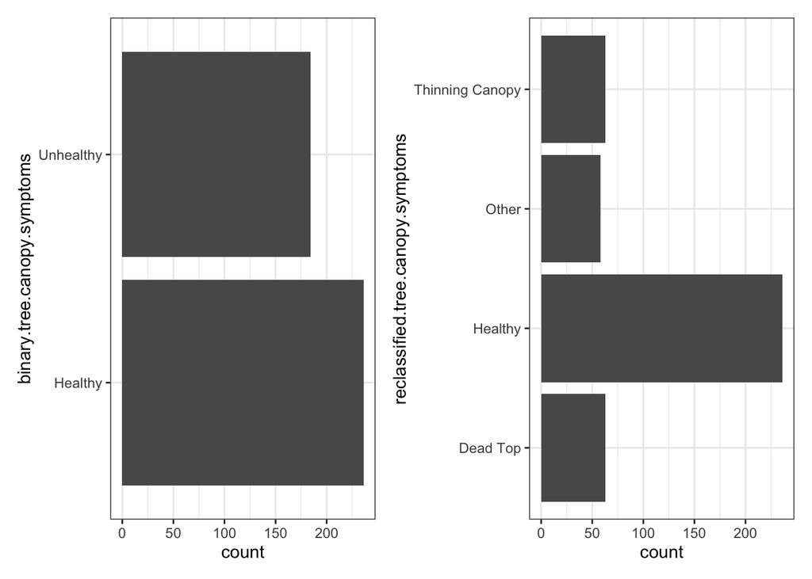

```r
p1 <- ggplot(data,aes(binary.tree.canopy.symptoms))+geom_histogram(stat="count")+theme_bw()+coord_flip()
p2 <- ggplot(data,aes(reclassified.tree.canopy.symptoms))+geom_histogram(stat="count")+theme_bw()+coord_flip()
p1 + p2
```

```r
p3 <-ggplot(data,aes(binary.tree.canopy.symptoms,DN_AF1, fill=binary.tree.canopy.symptoms ))+geom_boxplot(alpha=0.5)+theme_bw()+coord_flip() + scale_fill_manual(name="Tree Condition",values=c("#7fcdbb","#fe9929"))+guides(fill=FALSE) +labs(x="Tree Condition",y=NULL)
p4 <-ggplot(data,aes(DN_AF1,fill=binary.tree.canopy.symptoms))+geom_density(alpha=0.5) + scale_fill_manual(name="Tree Condition",values=c("#7fcdbb","#fe9929")) +theme_bw() +labs(x="Afternoon Temperature") +guides(fill=FALSE)
```

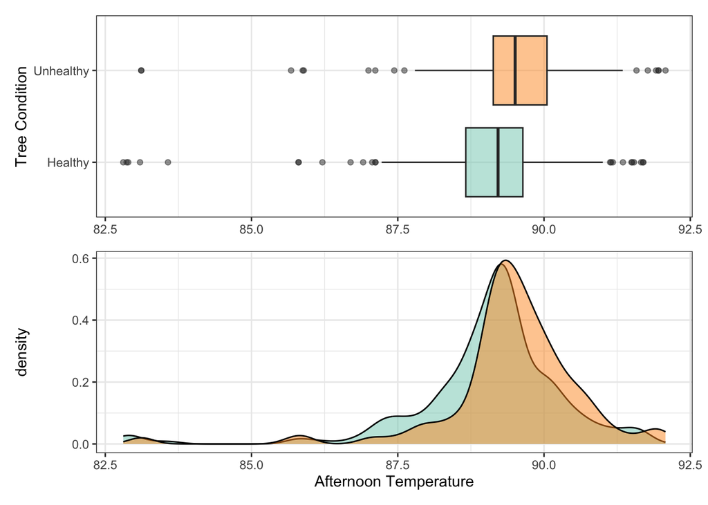

```r
p3 / p4
```

# Analyses

## Time Series Model Fit

```r
data$top.dieback <- as.factor(data$top.dieback)
data$thinning <- as.factor(data$thinning)
```

```r
binomial.daily <- glmmTMB(binary.tree.canopy.symptoms ~ mean.temp.daily ,family=binomial,data=data)
binomial.am <- glmmTMB(binary.tree.canopy.symptoms ~ DN_AM1 ,data=data,family=binomial)
binomial.af <- glmmTMB(binary.tree.canopy.symptoms ~ DN_AF1 ,data=data,family=binomial)
binomial.pm <- glmmTMB(binary.tree.canopy.symptoms ~ DN_PM1,data=data,family=binomial)
```

#### Best Fit Comparison

```r
AICtab(binomial.daily,binomial.am,binomial.af,binomial.pm)
```

```
##                dAIC df
## binomial.af     0.0 2
## binomial.am     8.9 2
## binomial.pm    11.4 2
## binomial.daily 11.7 2
```

Afternoon temperature was the best fit model

## Afternoon Temperatures

### Response 1.0: healthy / unhealthy

```r
binomial.af <- glmmTMB(binary.tree.canopy.symptoms ~ DN_AF1,data=data,family=binomial)
```

#### Summary

```r
summary(binomial.af)
```

```
##  Family: binomial  ( logit )
## Formula:          binary.tree.canopy.symptoms ~ DN_AF1
## Data: data
##
##      AIC      BIC   logLik deviance df.resid
##    568.1    576.1   -282.0    564.1      418
##
##
## Conditional model:
##              Estimate Std. Error z value Pr(>|z|)
## (Intercept) -25.95480    8.10408  -3.203  0.00136 **
## DN_AF1        0.28792    0.09074   3.173  0.00151 **
## ---
## Signif. codes:  0 '***' 0.001 '**' 0.01 '*' 0.05 '.' 0.1 ' ' 1
```

```r
levels(data$binary.tree.canopy.symptoms)
```

```
## [1] "Healthy"   "Unhealthy"
```

### Response 2.0: healthy / top-dieback

```r
data.top <- data %>% filter(reclassified.tree.canopy.symptoms=="Healthy"|reclassified.tree.canopy.symptoms=="Dead Top") %>% droplevels()
```

```r
top.dieback.binomial.af <- glmmTMB(top.dieback ~ DN_AF1,data=data.top,family=binomial)
```

#### Summary

```r
summary(top.dieback.binomial.af)
```

```
##  Family: binomial  ( logit )
## Formula:          top.dieback ~ DN_AF1
## Data: data.top
##
##      AIC      BIC   logLik deviance df.resid
##    296.7    304.1   -146.4    292.7      297
##
##
## Conditional model:
##             Estimate Std. Error z value Pr(>|z|)
## (Intercept) -51.4452    14.5502  -3.536 0.000407 ***
## DN_AF1        0.5607     0.1625   3.451 0.000558 ***
## ---
## Signif. codes:  0 '***' 0.001 '**' 0.01 '*' 0.05 '.' 0.1 ' ' 1
```

```r
levels(data$top.dieback)
```

```
## [1] "No"  "Yes"
```

#### Visualize effects of predictors

First, generate predictions from model

```r
# Create a data frame for predictions
new.data.2 <- expand.grid(
  DN_AF1 = seq(min(80), max(150), length.out = 1000)  # keeping predictor2 constant at its mean
)
```

```r
new.data.2$predicted_response <- predict(top.dieback.binomial.af, newdata = new.data.2, type = "response")
```

```r
# Create a data frame for predictions
new.data.2.inf <- expand.grid(
  DN_AF1 = seq(min(80), max(150), length.out = 1000)  # keeping predictor2 constant at its mean
)
```

```r
new.data.2.inf$predicted_response <- predict(top.dieback.binomial.af, newdata = new.data.2.inf, type = "response")
```

```r
head(new.data.2)
```

```
##     DN_AF1 predicted_response
## 1 80.00000        0.001371565
## 2 80.07007        0.001426445
## 3 80.14014        0.001483516
## 4 80.21021        0.001542868
## 5 80.28028        0.001604590
## 6 80.35035        0.001668777
```

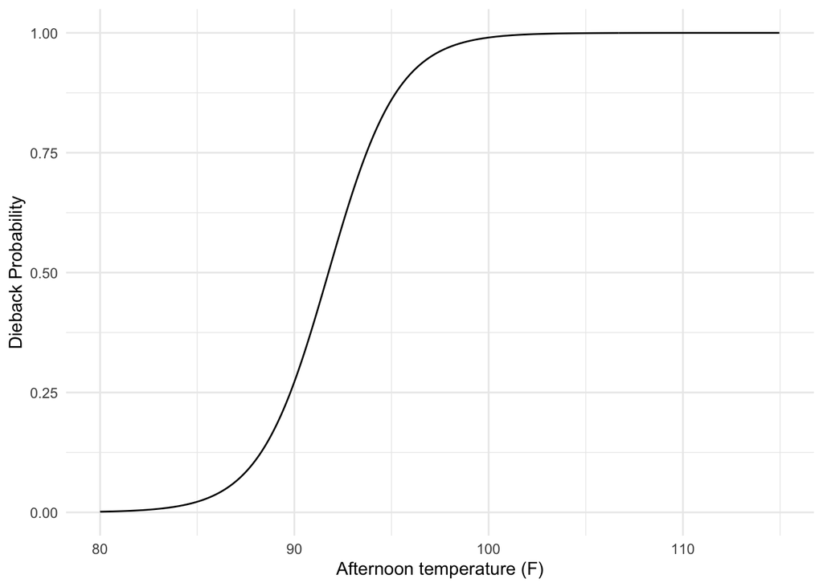

```r
p <- ggplot(new.data.2.inf, aes(x = DN_AF1, y = predicted_response)) + geom_line() + labs(x = "Afternoon temperature (F)", y = "Dieback Probability") + scale_x_continuous(limits = c(80, 115)) +theme_minimal()

p
```

### Calculate Dieback Probability Categories

```r
head(new.data.2[new.data.2$DN_AF1<85.5 & new.data.2$DN_AF1>84.75,])
```

```
##      DN_AF1 predicted_response
## 69 84.76476         0.01947612
## 70 84.83483         0.02024072
## 71 84.90490         0.02103468
## 72 84.97497         0.02185910
## 73 85.04505         0.02271508
## 74 85.11512         0.02360378
```

King County Trees at 85 degrees F had about a 0.023 probability

```r
head(new.data.2[new.data.2$predicted_response>0.024 & new.data.2$predicted_response<0.026,])
```

```
##      DN_AF1 predicted_response
## 75 85.18519         0.02452636
## 76 85.25526         0.02548407
```

King County trees at 85.22 had about a 0.025 probablilty

```r
head(new.data.2[new.data.2$predicted_response>0.048 & new.data.2$predicted_response<0.052,])
```

```
##      DN_AF1 predicted_response
## 93 86.44645         0.04852177
## 94 86.51652         0.05036807
```

King County trees at 86.5 had a 0.05 probability

```r
head(new.data.2[new.data.2$predicted_response>0.095 & new.data.2$predicted_response<0.105,,])
```

```
##       DN_AF1 predicted_response
## 112 87.77778         0.09712838
## 113 87.84785         0.10062860
## 114 87.91792         0.10424040
```

trees at about 87.8 degrees had a 0.1 predicted response.

```r
head(new.data.2[new.data.2$predicted_response>0.24,])
```

```
##       DN_AF1 predicted_response
## 140 89.73974          0.2442526
## 141 89.80981          0.2515774
## 142 89.87988          0.2590466
## 143 89.94995          0.2666585
## 144 90.02002          0.2744113
## 145 90.09009          0.2823027
```

King County Trees at 89.78 had about a 0.25 probability

- King County Top-Dieback Probability Categories (10%)
  - Most Concern (>10%): >87.8
  - Moderate Concern (2.5-10%): 85.22-87.8
  - Lowest Concern (<2.5%): <85.22
- King County Top-Dieback Probability Categories (25%)
  - Most Concern (>25%): 89.78
  - Moderate Concern (5-25%): 86.5 - 89.78
  - Lowest Concern (<5%): <86.5

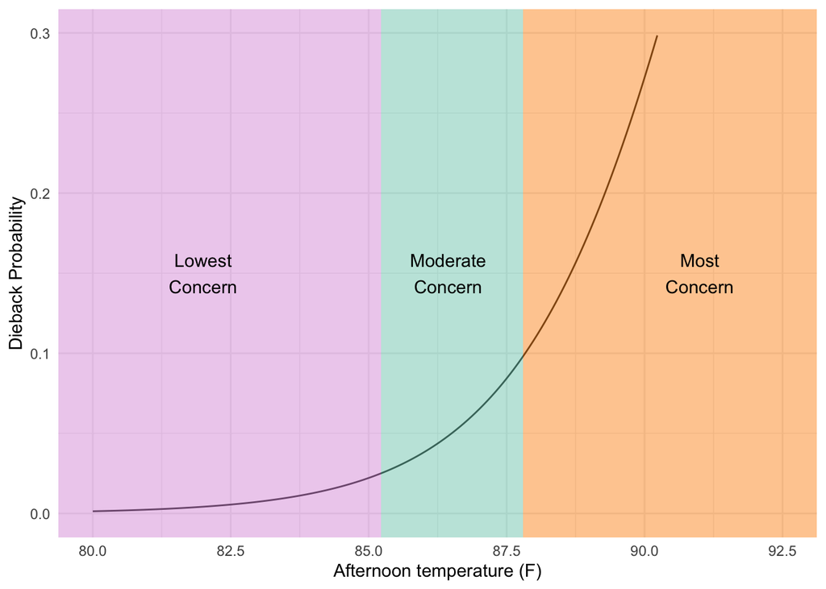

```r
p <- ggplot(new.data.2, aes(x = DN_AF1, y = predicted_response)) + geom_line() + labs(x = "Afternoon temperature (F)", y = "Dieback Probability") + scale_x_continuous(limits = c(80, 92.5),breaks=c(80,82.5,85,87.5,90,92.5)) + scale_y_continuous(limits = c(0, .3)) +theme_minimal()

p2 <- p + annotate(geom="rect",ymin = -Inf, ymax = Inf,
              xmin = -Inf, xmax = 85.22, fill = alpha('#DDA0DD',0.5)) +
    annotate(geom="rect",ymin = -Inf, ymax = Inf,
              xmin = 85.22, xmax = 87.8, fill = alpha('#7fcdbb',0.5)) +
    annotate(geom="rect",ymin = -Inf, ymax = Inf,
          xmin = 87.8, xmax = Inf, fill = alpha('#fe9929',0.5))
p3 <- p2 + annotate("text", x=82, y=.15, label= "Lowest\nConcern") + annotate("text", x=86.44, y=.15, label= "Moderate\nConcern") + annotate("text", x=91, y=.15, label= "Most\nConcern")
p3
```

The probability of a tree having top dieback increases with afternoon temperature

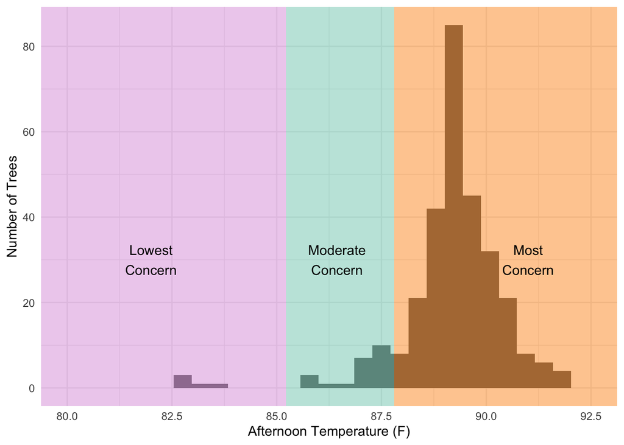

```r
p <- ggplot(data.top, aes(x=DN_AF1))+geom_histogram() +theme_minimal() +labs(y="Number of Trees",x="Afternoon Temperature (F)") + scale_x_continuous(limits = c(80, 92.5),breaks=c(80,82.5,85,87.5,90,92.5))

p2 <- p + annotate(geom="rect",ymin = -Inf, ymax = Inf,
              xmin = -Inf, xmax = 85.22, fill = alpha('#DDA0DD',0.5)) +
    annotate(geom="rect",ymin = -Inf, ymax = Inf,
              xmin = 85.22, xmax = 87.8, fill = alpha('#7fcdbb',0.5)) +
    annotate(geom="rect",ymin = -Inf, ymax = Inf,
          xmin = 87.8, xmax = Inf, fill = alpha('#fe9929',0.5))
p3 <- p2 + annotate("text", x=82, y=30, label= "Lowest\nConcern") + annotate("text", x=86.44, y=30, label= "Moderate\nConcern") + annotate("text", x=91, y=30, label= "Most\nConcern")
p3
```

### Response 3.0: healthy / thinning

```r
data.thin <- data %>% filter(reclassified.tree.canopy.symptoms=="Healthy"|reclassified.tree.canopy.symptoms=="Thinning Canopy") %>% droplevels()
```

```r
thinning.binomial.af <- glmmTMB(thinning ~ DN_AF1,data=data.thin,family=binomial)
```

#### Summary

```r
summary(thinning.binomial.af)
```

```
##  Family: binomial  ( logit )
## Formula:          thinning ~ DN_AF1
## Data: data.thin
##
##      AIC      BIC   logLik deviance df.resid
##    302.2    309.6   -149.1    298.2      297
##
##
## Conditional model:
##             Estimate Std. Error z value Pr(>|z|)
## (Intercept) -38.9374    13.3769  -2.911  0.00361 **
## DN_AF1        0.4211     0.1495   2.817  0.00485 **
## ---
## Signif. codes:  0 '***' 0.001 '**' 0.01 '*' 0.05 '.' 0.1 ' ' 1
```

```r
levels(data$thinning)
```

```
## [1] "No"  "Yes"
```

# Overall Summary

The probability of a tree having top dieback increases with afternoon temperature

| Area | Response | Explanatory | df.resid | Estimate | Std.Error | z-val | Pr(>z) | Signif. |
| --- | --- | --- | --- | --- | --- | --- | --- | --- |
| King County | healthy/unhealthy | DN_AF | 418 | 0.28792 | 0.09074 | 3.173 | 0.00151 | ** |
| King County | no/dead-top | DN_AF | 297 | 0.5607 | 0.1625 | 3.451 | 0.000558 | *** |
| King County | no/thinning | DN_AF | 297 | 0.4211 | 0.1495 | 2.817 | 0.00485 | ** |